# Прогнозные модели для фермера

На основе 3 датасетов необходимо составить прогнозные модели, которые смогут прогнозировать будущий удой коровы и рассчитывать вероятность получения вкусного молока. С помощью модели нужно отобрать коров по двум критериям: средний удой за год — не менее 6000 килограммов, молоко должно быть вкусным.

## Импорт библиотек

```python
import pandas as pd
import matplotlib.pyplot as plt
import numpy as np
!pip install phik -q
from phik import resources, report
import seaborn as sns
import scipy.stats as stats
from scipy.stats import spearmanr
from sklearn.model_selection import train_test_split
from sklearn.preprocessing import OneHotEncoder, StandardScaler
from sklearn.linear_model import LinearRegression, LogisticRegression
from sklearn.metrics import (
    r2_score,
    mean_absolute_error,
    mean_squared_error,
    accuracy_score,
    precision_score,
    recall_score,
    confusion_matrix)
```

## Загрузка данных

Создание датасетов на основе файлов, изучение данных и переименование столбцов.

```python
df1 = pd.read_csv('/datasets/ferma_main.csv', sep = ';', decimal = ',')
df2 = pd.read_csv('/datasets/ferma_dad.csv', sep = ';', decimal = ',')
df3 = pd.read_csv('/datasets/cow_buy.csv', sep = ';', decimal = ',')
```

```python
df1_old_names = df1.columns
df1.columns = ['id', 'yield_kg', 'EKE', 'raw_protein_g', 'sugar_protein_ratio', 'breed', 'grassland_type', 'dad_breed', 'fat_percent', 'protein_percent', 'milk_taste', 'age']
display(df1.sample(5))
display(df1.describe())
display(df1.info())
```

|  | id | yield_kg | EKE | raw_protein_g | sugar_protein_ratio | breed | grassland_type | dad_breed | fat_percent | protein_percent | milk_taste | age |
| --- | --- | --- | --- | --- | --- | --- | --- | --- | --- | --- | --- | --- |
| 568 | 569 | 5989 | 13.2 | 1721 | 0.86 | Вис Бик Айдиал | Холмистое | Соверин | 2.99 | 3.076 | вкусно | менее_2_лет |
| 399 | 400 | 5561 | 12.6 | 1692 | 0.89 | Вис Бик Айдиал | Холмистое | Соверин | 3.59 | 3.079 | вкусно | менее_2_лет |
| 492 | 493 | 5848 | 13.1 | 1791 | 0.88 | РефлешнСоверинг | Равнинное | Айдиал | 3.62 | 3.072 | вкусно | более_2_лет |
| 499 | 500 | 6601 | 15.4 | 1963 | 0.94 | РефлешнСоверинг | Равнинное | Айдиал | 3.71 | 3.076 | вкусно | более_2_лет |
| 109 | 110 | 6414 | 13.9 | 1808 | 0.93 | Вис Бик Айдиал | Равнинное | Айдиал | 3.73 | 3.078 | вкусно | более_2_лет |

|  | id | yield_kg | EKE | raw_protein_g | sugar_protein_ratio | fat_percent | protein_percent |
| --- | --- | --- | --- | --- | --- | --- | --- |
| count | 634.000000 | 634.000000 | 634.000000 | 634.000000 | 634.000000 | 634.000000 | 634.000000 |
| mean | 317.460568 | 6187.025237 | 14.542744 | 1922.682965 | 0.912855 | 3.603943 | 3.075666 |
| std | 183.096982 | 1638.401021 | 1.301301 | 182.392548 | 0.032209 | 0.168020 | 0.002540 |
| min | 1.000000 | 5204.000000 | 10.900000 | 1660.000000 | 0.840000 | 2.990000 | 3.069000 |
| 25% | 159.250000 | 5751.750000 | 13.500000 | 1772.250000 | 0.890000 | 3.590000 | 3.074000 |
| 50% | 317.500000 | 6130.500000 | 14.700000 | 1880.500000 | 0.930000 | 3.650000 | 3.076000 |
| 75% | 475.750000 | 6501.000000 | 15.600000 | 2058.750000 | 0.940000 | 3.720000 | 3.077000 |
| max | 629.000000 | 45616.000000 | 16.800000 | 2349.000000 | 0.960000 | 3.750000 | 3.085000 |

```
<class 'pandas.core.frame.DataFrame'>
RangeIndex: 634 entries, 0 to 633
Data columns (total 12 columns):
 #   Column               Non-Null Count  Dtype
---  ------               --------------  -----
 0   id                   634 non-null    int64
 1   yield_kg             634 non-null    int64
 2   EKE                  634 non-null    float64
 3   raw_protein_g        634 non-null    int64
 4   sugar_protein_ratio  634 non-null    float64
 5   breed                634 non-null    object
 6   grassland_type       634 non-null    object
 7   dad_breed            634 non-null    object
 8   fat_percent          634 non-null    float64
 9   protein_percent      634 non-null    float64
 10  milk_taste           634 non-null    object
 11  age                  634 non-null    object
dtypes: float64(4), int64(3), object(5)
memory usage: 59.6+ KB
```

```
None
```

```python
df2_old_names = df2.columns
df2.columns = ['id','dad_name']
display(df2.sample(5))
display(df2.describe())
display(df2.info())
```

|  | id | dad_name |
| --- | --- | --- |
| 627 | 628 | Барин |
| 53 | 54 | Барин |
| 312 | 313 | Соловчик |
| 587 | 588 | Буйный |
| 588 | 589 | Барин |

|  | id |
| --- | --- |
| count | 629.00000 |
| mean | 315.00000 |
| std | 181.72094 |
| min | 1.00000 |
| 25% | 158.00000 |
| 50% | 315.00000 |
| 75% | 472.00000 |
| max | 629.00000 |

```
<class 'pandas.core.frame.DataFrame'>
RangeIndex: 629 entries, 0 to 628
Data columns (total 2 columns):
 #   Column    Non-Null Count  Dtype
---  ------    --------------  -----
 0   id        629 non-null    int64
 1   dad_name  629 non-null    object
dtypes: int64(1), object(1)
memory usage: 10.0+ KB
```

```
None
```

```python
df3_old_names = df3.columns
df3.columns = ['breed', 'grassland_type', 'dad_breed', 'dad_name', 'current_fat_percent', 'current_protein_percent', 'age']

display(df3.sample(5))
display(df3.describe())
display(df3.info())
```

|  | breed | grassland_type | dad_breed | dad_name | current_fat_percent | current_protein_percent | age |
| --- | --- | --- | --- | --- | --- | --- | --- |
| 19 | РефлешнСоверинг | равнинное | Айдиал | Буйный | 3.64 | 3.074 | более_2_лет |
| 8 | РефлешнСоверинг | равнинное | Соверин | Барин | 3.59 | 3.074 | более_2_лет |
| 7 | Вис Бик Айдиал | равнинное | Соверин | Буйный | 3.57 | 3.079 | более_2_лет |
| 12 | Вис Бик Айдиал | холмистое | Айдиал | Геркулес | 3.68 | 3.046 | более_2_лет |
| 1 | Вис Бик Айдиал | равнинное | Соверин | Буйный | 3.54 | 3.081 | менее_2_лет |

|  | current_fat_percent | current_protein_percent |
| --- | --- | --- |
| count | 20.000000 | 20.000000 |
| mean | 3.577500 | 3.069500 |
| std | 0.126818 | 0.010339 |
| min | 3.340000 | 3.046000 |
| 25% | 3.510000 | 3.064000 |
| 50% | 3.590000 | 3.074000 |
| 75% | 3.650000 | 3.076000 |
| max | 3.770000 | 3.081000 |

```
<class 'pandas.core.frame.DataFrame'>
RangeIndex: 20 entries, 0 to 19
Data columns (total 7 columns):
 #   Column                   Non-Null Count  Dtype
---  ------                   --------------  -----
 0   breed                    20 non-null     object
 1   grassland_type           20 non-null     object
 2   dad_breed                20 non-null     object
 3   dad_name                 20 non-null     object
 4   current_fat_percent      20 non-null     float64
 5   current_protein_percent  20 non-null     float64
 6   age                      20 non-null     object
dtypes: float64(2), object(5)
memory usage: 1.2+ KB
```

```
None
```

Загружены 3 датасета, наименования столбцов заданы на английском для удобства работы. В датасете df1 замечено аномально высокое максимальное значение в столбце yield_kg. Предобработка и исследовательский анализ будут проведены далее.

## Предобработка данных

```python
print('Количество дупликатов в df1:', df1.duplicated().sum())
display(df1[df1.duplicated(keep=False)])
print('Количество пропусков в df1:', df1.isna().sum())

df1 = df1.drop_duplicates()
display(df1.info())

# Удалены коровы с одинаковыми признаками, включая id
```

```
Количество дупликатов в df1: 5
```

|  | id | yield_kg | EKE | raw_protein_g | sugar_protein_ratio | breed | grassland_type | dad_breed | fat_percent | protein_percent | milk_taste | age |
| --- | --- | --- | --- | --- | --- | --- | --- | --- | --- | --- | --- | --- |
| 626 | 627 | 5970 | 14.4 | 1837 | 0.88 | РефлешнСоверинг | Холмистое | Соверин | 3.64 | 3.075 | не вкусно | более_2_лет |
| 629 | 627 | 5970 | 14.4 | 1837 | 0.88 | РефлешнСоверинг | Холмистое | Соверин | 3.64 | 3.075 | не вкусно | более_2_лет |
| 630 | 627 | 5970 | 14.4 | 1837 | 0.88 | РефлешнСоверинг | Холмистое | Соверин | 3.64 | 3.075 | не вкусно | более_2_лет |
| 631 | 627 | 5970 | 14.4 | 1837 | 0.88 | РефлешнСоверинг | Холмистое | Соверин | 3.64 | 3.075 | не вкусно | более_2_лет |
| 632 | 627 | 5970 | 14.4 | 1837 | 0.88 | РефлешнСоверинг | Холмистое | Соверин | 3.64 | 3.075 | не вкусно | более_2_лет |
| 633 | 627 | 5970 | 14.4 | 1837 | 0.88 | РефлешнСоверинг | Холмистое | Соверин | 3.64 | 3.075 | не вкусно | более_2_лет |

```
Количество пропусков в df1: id                     0
yield_kg               0
EKE                    0
raw_protein_g          0
sugar_protein_ratio    0
breed                  0
grassland_type         0
dad_breed              0
fat_percent            0
protein_percent        0
milk_taste             0
age                    0
dtype: int64
<class 'pandas.core.frame.DataFrame'>
Int64Index: 629 entries, 0 to 628
Data columns (total 12 columns):
 #   Column               Non-Null Count  Dtype
---  ------               --------------  -----
 0   id                   629 non-null    int64
 1   yield_kg             629 non-null    int64
 2   EKE                  629 non-null    float64
 3   raw_protein_g        629 non-null    int64
 4   sugar_protein_ratio  629 non-null    float64
 5   breed                629 non-null    object
 6   grassland_type       629 non-null    object
 7   dad_breed            629 non-null    object
 8   fat_percent          629 non-null    float64
 9   protein_percent      629 non-null    float64
 10  milk_taste           629 non-null    object
 11  age                  629 non-null    object
dtypes: float64(4), int64(3), object(5)
memory usage: 63.9+ KB
```

```
None
```

```python
print('Количество дупликатов в df2:', df2.duplicated().sum())
display(df2[df2.duplicated()])
print('Количество пропусков в df2:', df2.isna().sum())
display(df2.info())
```

```
Количество дупликатов в df2: 0
```

|  | id | dad_name |
| --- | --- | --- |

```
Количество пропусков в df2: id          0
dad_name    0
dtype: int64
<class 'pandas.core.frame.DataFrame'>
RangeIndex: 629 entries, 0 to 628
Data columns (total 2 columns):
 #   Column    Non-Null Count  Dtype
---  ------    --------------  -----
 0   id        629 non-null    int64
 1   dad_name  629 non-null    object
dtypes: int64(1), object(1)
memory usage: 10.0+ KB
```

```
None
```

```python
print('Количество дупликатов в df3:', df3.duplicated().sum())
display(df3[df3.duplicated(keep=False)])
print('Количество пропусков в df3:', df3.isna().sum())

display(df3.info())

# Дубликаты в df3 по смыслу не являются дубликатами, поскольку вероятно, что две разных коровы-кандидата могут иметь абсолютно идентичные признаки
```

```
Количество дупликатов в df3: 4
```

|  | breed | grassland_type | dad_breed | dad_name | current_fat_percent | current_protein_percent | age |
| --- | --- | --- | --- | --- | --- | --- | --- |
| 0 | Вис Бик Айдиал | холмистое | Айдиал | Геркулес | 3.58 | 3.076 | более_2_лет |
| 2 | РефлешнСоверинг | равнинное | Соверин | Барин | 3.59 | 3.074 | более_2_лет |
| 4 | РефлешнСоверинг | равнинное | Айдиал | Буйный | 3.64 | 3.074 | более_2_лет |
| 6 | Вис Бик Айдиал | холмистое | Айдиал | Геркулес | 3.58 | 3.076 | более_2_лет |
| 8 | РефлешнСоверинг | равнинное | Соверин | Барин | 3.59 | 3.074 | более_2_лет |
| 14 | РефлешнСоверинг | равнинное | Соверин | Барин | 3.59 | 3.074 | более_2_лет |
| 19 | РефлешнСоверинг | равнинное | Айдиал | Буйный | 3.64 | 3.074 | более_2_лет |

```
Количество пропусков в df3: breed                      0
grassland_type             0
dad_breed                  0
dad_name                   0
current_fat_percent        0
current_protein_percent    0
age                        0
dtype: int64
<class 'pandas.core.frame.DataFrame'>
RangeIndex: 20 entries, 0 to 19
Data columns (total 7 columns):
 #   Column                   Non-Null Count  Dtype
---  ------                   --------------  -----
 0   breed                    20 non-null     object
 1   grassland_type           20 non-null     object
 2   dad_breed                20 non-null     object
 3   dad_name                 20 non-null     object
 4   current_fat_percent      20 non-null     float64
 5   current_protein_percent  20 non-null     float64
 6   age                      20 non-null     object
dtypes: float64(2), object(5)
memory usage: 1.2+ KB
```

```
None
```

Датасеты изучены на типы данных столбцов, наличие пропусков и дубликатов. Из df1 удалены 5 полных дубликатов.

## Исследовательский анализ данных

Изучение df1

```
<class 'pandas.core.frame.DataFrame'>
Int64Index: 629 entries, 0 to 628
Data columns (total 12 columns):
 #   Column               Non-Null Count  Dtype
---  ------               --------------  -----
 0   id                   629 non-null    int64
 1   yield_kg             629 non-null    int64
 2   EKE                  629 non-null    float64
 3   raw_protein_g        629 non-null    int64
 4   sugar_protein_ratio  629 non-null    float64
 5   breed                629 non-null    object
 6   grassland_type       629 non-null    object
 7   dad_breed            629 non-null    object
 8   fat_percent          629 non-null    float64
 9   protein_percent      629 non-null    float64
 10  milk_taste           629 non-null    object
 11  age                  629 non-null    object
dtypes: float64(4), int64(3), object(5)
memory usage: 63.9+ KB
```

```
None
```

|  | id | yield_kg | EKE | raw_protein_g | sugar_protein_ratio | fat_percent | protein_percent |
| --- | --- | --- | --- | --- | --- | --- | --- |
| count | 629.00000 | 629.000000 | 629.000000 | 629.000000 | 629.000000 | 629.000000 | 629.000000 |
| mean | 315.00000 | 6188.750397 | 14.543879 | 1923.364070 | 0.913116 | 3.603657 | 3.075671 |
| std | 181.72094 | 1644.795489 | 1.306408 | 182.956251 | 0.032203 | 0.168656 | 0.002549 |
| min | 1.00000 | 5204.000000 | 10.900000 | 1660.000000 | 0.840000 | 2.990000 | 3.069000 |
| 25% | 158.00000 | 5751.000000 | 13.500000 | 1771.000000 | 0.890000 | 3.590000 | 3.074000 |
| 50% | 315.00000 | 6133.000000 | 14.700000 | 1888.000000 | 0.930000 | 3.650000 | 3.076000 |
| 75% | 472.00000 | 6501.000000 | 15.600000 | 2062.000000 | 0.940000 | 3.720000 | 3.077000 |
| max | 629.00000 | 45616.000000 | 16.800000 | 2349.000000 | 0.960000 | 3.750000 | 3.085000 |

|  | id | yield_kg | EKE | raw_protein_g | sugar_protein_ratio | breed | grassland_type | dad_breed | fat_percent | protein_percent | milk_taste | age |
| --- | --- | --- | --- | --- | --- | --- | --- | --- | --- | --- | --- | --- |
| 307 | 308 | 5936 | 13.2 | 1993 | 0.89 | Вис Бик Айдиал | Равнинное | Айдиал | 3.64 | 3.076 | вкусно | более_2_лет |
| 338 | 339 | 6184 | 15.1 | 1764 | 0.94 | РефлешнСоверинг | Холмистое | Соверин | 3.74 | 3.077 | вкусно | более_2_лет |
| 20 | 21 | 6752 | 15.5 | 1924 | 0.93 | РефлешнСоверинг | Холмистое | Айдиалл | 3.73 | 3.078 | вкусно | более_2_лет |
| 490 | 491 | 5842 | 13.2 | 1836 | 0.85 | РефлешнСоверинг | Холмистое | Айдиал | 3.28 | 3.076 | вкусно | более_2_лет |
| 574 | 575 | 6156 | 14.6 | 1955 | 0.94 | РефлешнСоверинг | Холмистое | Соверин | 3.73 | 3.077 | вкусно | более_2_лет |

```
array([[<AxesSubplot:title={'center':'id'}>,
        <AxesSubplot:title={'center':'yield_kg'}>,
        <AxesSubplot:title={'center':'EKE'}>],
       [<AxesSubplot:title={'center':'raw_protein_g'}>,
        <AxesSubplot:title={'center':'sugar_protein_ratio'}>,
        <AxesSubplot:title={'center':'fat_percent'}>],
       [<AxesSubplot:title={'center':'protein_percent'}>, <AxesSubplot:>,
        <AxesSubplot:>]], dtype=object)
```

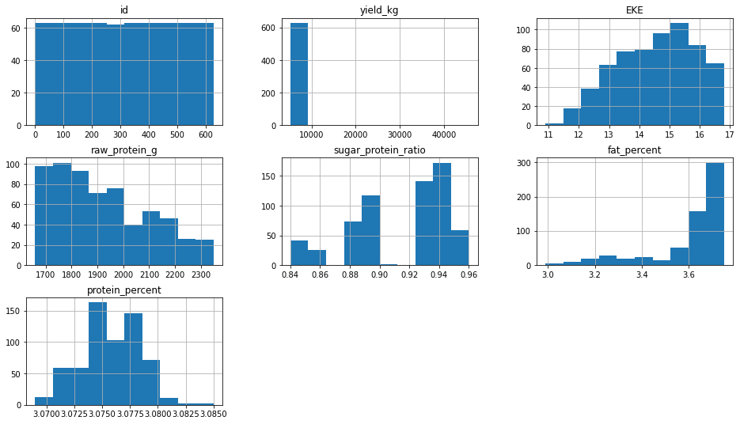

```python
display(df1.info())
display(df1.describe())
display(df1.sample(5))
display(df1.hist(figsize = (16,9)));
```

```python
# Изучение столбца id
print('Количество дубликатов в столбце id:', df1['id'].duplicated().sum())
print('Количество уникальных значений в столбце id:', len(df1['id'].unique()))
```

```
Количество дубликатов в столбце id: 0
Количество уникальных значений в столбце id: 629
```

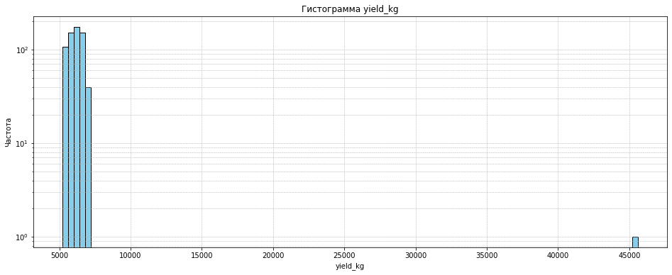

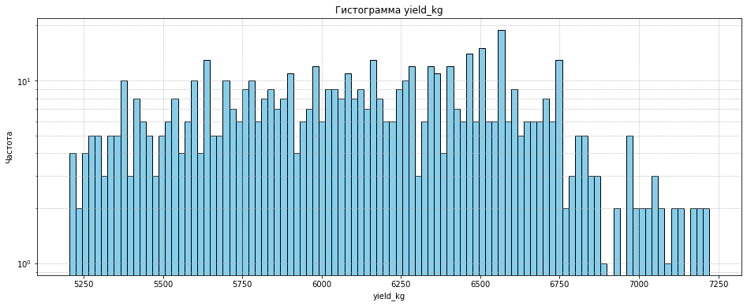

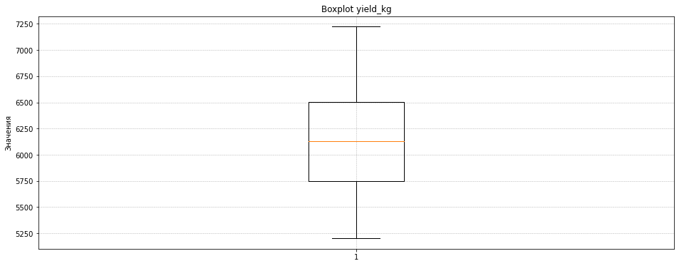

```python
# Изучение столбца yiled_kg

name = 'yield_kg'

plt.figure(figsize=(16, 6))
plt.hist(df1[name], bins=100, color='skyblue', edgecolor='black')
plt.title(f'Гистограмма {name}')
plt.xlabel(name)
plt.ylabel('Частота')
plt.yscale('log')
plt.grid(True, which='both', linestyle='--', linewidth=0.5)
plt.show()

# Удалил очевидно невозможный выброс
df1 = df1[df1[name] < 20000]

plt.figure(figsize=(16, 6))
plt.hist(df1[name], bins=100, color='skyblue', edgecolor='black')
plt.title(f'Гистограмма {name}')
plt.xlabel(name)
plt.ylabel('Частота')
plt.yscale('log')
plt.grid(True, which='both', linestyle='--', linewidth=0.5)
plt.show()

plt.figure(figsize=(16, 6))
plt.boxplot(df1[name])
plt.title(f'Boxplot {name}')
plt.ylabel('Значения')
plt.grid(True, which='both', linestyle='--', linewidth=0.5)
plt.show()

# В столбце выбросов не обнаружено после удаления
```

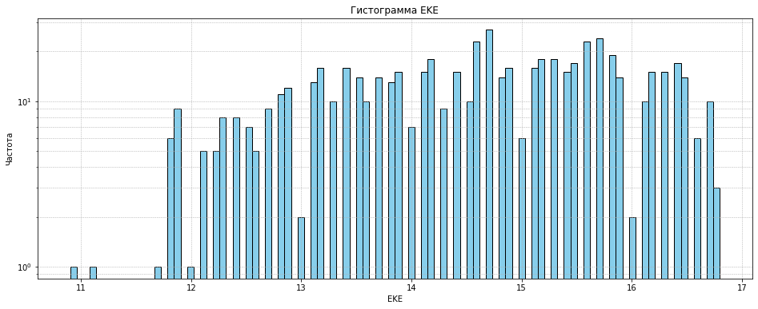

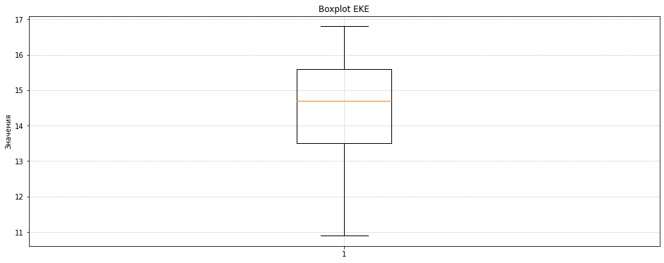

```python
# Изучение столбца EKE

name = 'EKE'

plt.figure(figsize=(16, 6))
plt.hist(df1[name], bins=100, color='skyblue', edgecolor='black')
plt.title(f'Гистограмма {name}')
plt.xlabel(name)
plt.ylabel('Частота')
plt.yscale('log')
plt.grid(True, which='both', linestyle='--', linewidth=0.5)
plt.show()


plt.figure(figsize=(16, 6))
plt.boxplot(df1[name])
plt.title(f'Boxplot {name}')
plt.ylabel('Значения')
plt.grid(True, which='both', linestyle='--', linewidth=0.5)
plt.show()

# В столбце выбросов не обнаружено
```

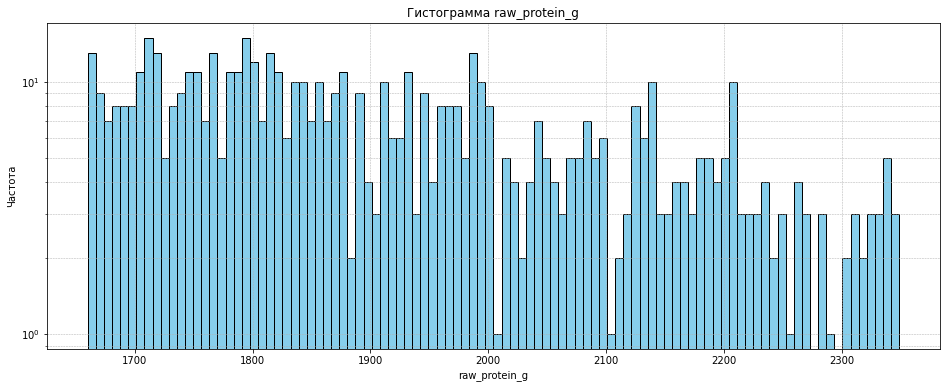

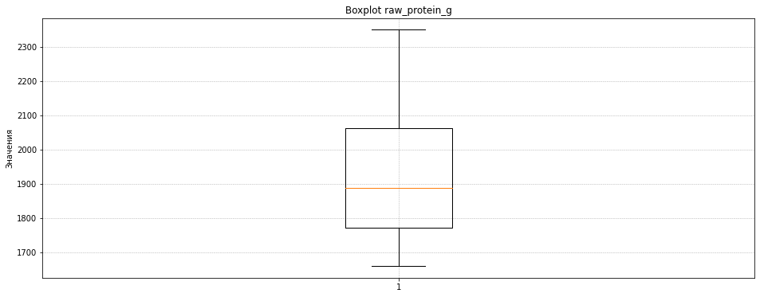

```python
# Изучение столбца raw_protein_g

name = 'raw_protein_g'

plt.figure(figsize=(16, 6))
plt.hist(df1[name], bins=100, color='skyblue', edgecolor='black')
plt.title(f'Гистограмма {name}')
plt.xlabel(name)
plt.ylabel('Частота')
plt.yscale('log')
plt.grid(True, which='both', linestyle='--', linewidth=0.5)
plt.show()


plt.figure(figsize=(16, 6))
plt.boxplot(df1[name])
plt.title(f'Boxplot {name}')
plt.ylabel('Значения')
plt.grid(True, which='both', linestyle='--', linewidth=0.5)
plt.show()

# В столбце выбросов не обнаружено
```

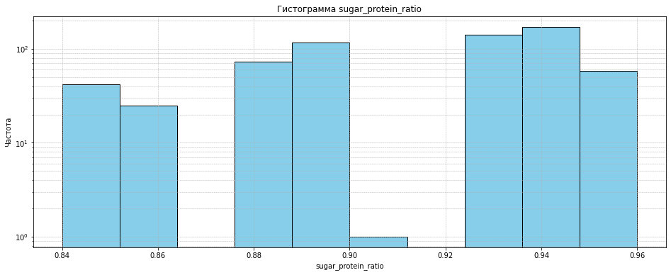

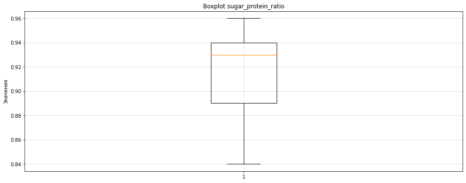

```python
# Изучение столбца sugar_protein_ratio

name = 'sugar_protein_ratio'

plt.figure(figsize=(16, 6))
plt.hist(df1[name], bins=10, color='skyblue', edgecolor='black')
plt.title(f'Гистограмма {name}')
plt.xlabel(name)
plt.ylabel('Частота')
plt.yscale('log')
plt.grid(True, which='both', linestyle='--', linewidth=0.5)
plt.show()

plt.figure(figsize=(16, 6))
plt.boxplot(df1[name])
plt.title(f'Boxplot {name}')
plt.ylabel('Значения')
plt.grid(True, which='both', linestyle='--', linewidth=0.5)
plt.show()

# В столбце выбросов не обнаружено
```